# PY0794: Lecture 6 - Worksheet

Dr. Thomas Pollet, Northumbria University, UK

2020-10-05

# Introduction.

This is a worksheet for use with [Lecture 6](https://tvpollet.github.io/PY_0794/Lecture_6/Lecture6-xaringan.html#1).

You have a [videos of me narrating these slides](https://www.youtube.com/playlist?list=PLeRo-gE9BBdxXVFx48CiQqyT19xgBL1eg) from 2019. Note that there are potentially minor discrepancies between the current set of slides and the one in the video. **The slide numbers refer to the current set.** I do not cover every single slide but you can code along!

If you answer correctly the colour of the box will change from red dashed to full blue! (Don’t worry about bonus questions, they are very much just that: a bonus!)

# Slides

## What is a mediation? (Slide 5)

Mediation has occurred when:

1. The strength of the relationship between a predictor variable and an outcome variable is reduced by including another variable in the model.
2. The strength of the relationship between a predictor variable and an outcome variable is increased by including another variable as a predictor.
3. The relationship between two variables changes as a function of a third variable.
4. The relationship between two variables decreases as a function of a third variable.

My answer:

Which of the following is an example of perfect mediation?

1. The strength of the relationship between the predictor and the outcome is reduced by exactly half when the mediator is included in the model.
2. The relationship between the predictor and the outcome remains the same when the mediator is included in the model.
3. The relationship between the predictor and the outcome is completely wiped out when the mediator is included in the model.
4. The interaction of the predictor and the mediator significantly predicts the outcome, but the variables themselves do not.

My answer:

You can read in more detail [here](https://www.ncbi.nlm.nih.gov/pmc/articles/PMC2819368/). The section on complete versus partial mediation might hold a clue.

## Check diagrammer tutorial? (Slide 12)

Suppose I would want to change how the tail of the arrow looks, which aesthetic (‘aes’) of the edge would we change?

My answer:

Have a look at the code on the slide and in particular ‘edge’. Remember that you can look into the help panel and then look at the edge aesthetics (edge_aes)

## How would you report it (Slide 26)

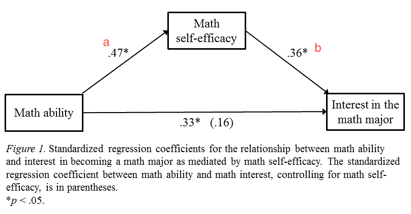

Have a look at the figure above. What would be ‘a’ and ‘b’ for our fictional example with X,M,Y (2 decimals, no need to include * annotation)?

Remember that these are standardised coefficients in the diagram ($\beta's$). So you’ll have to calculate these! Look back over your session 4 slides if you don’t remember how to do this.

Remember that there is no intercept in a model

a corresponds to step 2

b corresponds to step 3

## Try it yourself. (Slide 27)

Use the information on the previous slides.

## Three measures (Slide 31)

What was the Aroian *z* value for our example? (2 decimals)

Look back at slide 29

## Try it yourself. (Slide 36)

Use the information on the previous slides.

## Summary (Slide 40)

Notice the rounding has changed slightly.

The results suggest a complete mediation. (True of False)

The direct effect is no longer statistically significant. 90% of the effect is mediated (.9).

## Exercise (Slide 47-48)

Complete the exercise and submit via Blackboard!

# Going further.

- Have a look at resources made by Alex and Sarah.
- Have a look at the resources listed at the end.

# Session Info.

Thanks to Lisa DeBruine for the [webex](https://cran.r-project.org/web/packages/webex/index.html) package. Some of the multiple choice questions are from [Discovering Statistics by Andy Field](https://www.discoveringstatistics.com/books/an-adventure-in-statistics/). Please see [general disclaimer](https://tvpollet.github.io/disclaimer).

# The end…

[figure not shown]